# Phage and Plasmid Ecology Analyses (DWW)

# 4 4. Alpha Diversity

## 4.1 4.1 Prepare Count Tables

```r
votus_for_rich <- votus_clean %>%
  column_to_rownames(var = "sample") %>%
  mutate(across(where(is.character), as.numeric))

potus_for_rich <- potus_clean %>%
  column_to_rownames(var = "sample") %>%
  mutate(across(where(is.character), as.numeric))
```

## 4.2 4.2 Check Counts Distribution

```r
summary(rowSums(votus_for_rich))
```

```
##     Min.  1st Qu.   Median     Mean  3rd Qu.     Max.
##    71456  1823860  2512176  2634573  3180808 13046234
```

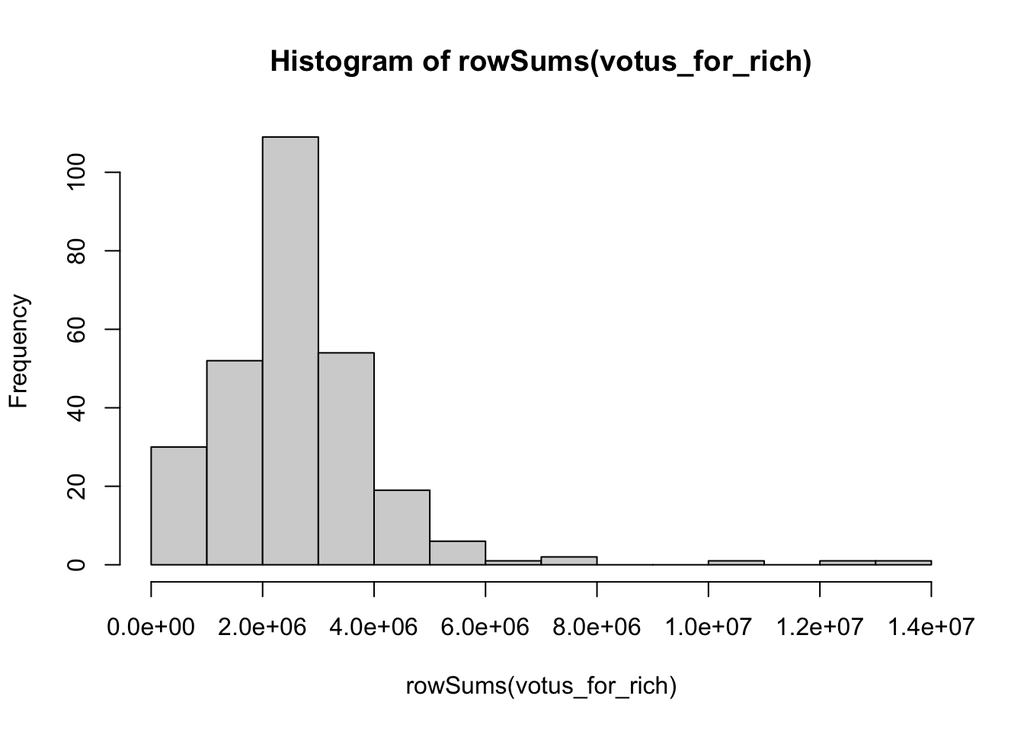

```r
hist(rowSums(votus_for_rich))
```

```r
summary(rowSums(potus_for_rich))
```

```
##     Min.  1st Qu.   Median     Mean  3rd Qu.     Max.
##    63508  1860945  2400765  2793385  3182912 11728692
```

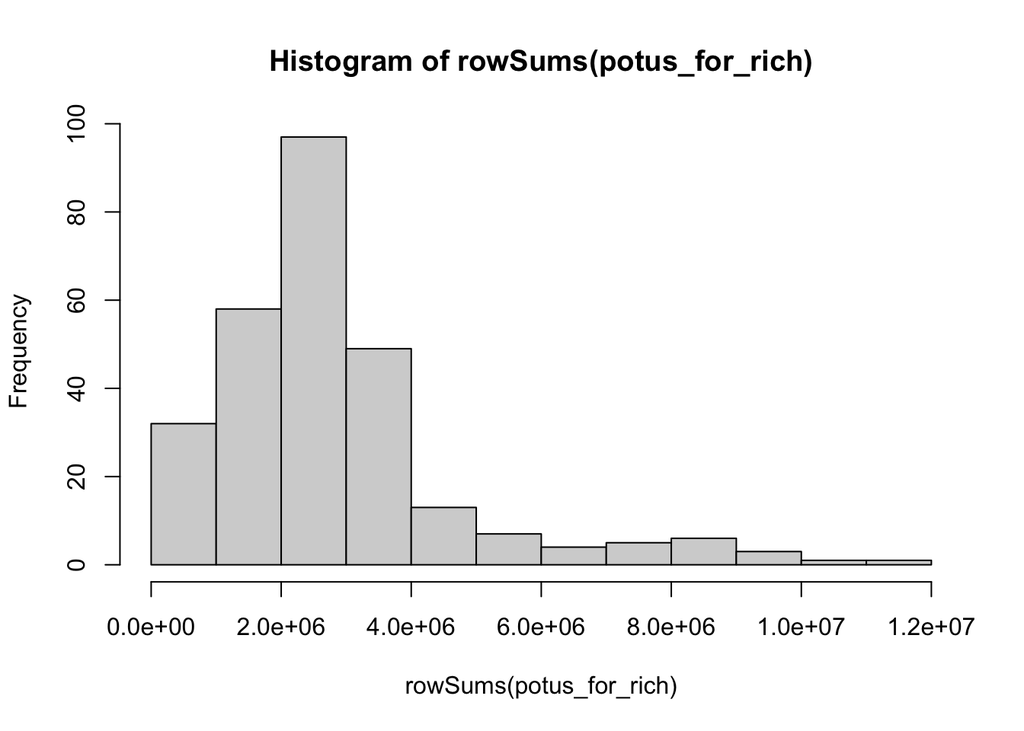

```r
hist(rowSums(potus_for_rich))
```

## 4.3 4.3 Calculate Diversity Measures

```r
md$viral_rich <- specnumber(rrarefy(votus_for_rich, sample = 71456))
md$viral_shannon <- diversity(rrarefy(votus_for_rich, sample = 71456), index = "shannon")
md$plasmid_rich <- specnumber(rrarefy(potus_for_rich, sample = 63508))
md$plasmid_shannon <- diversity(rrarefy(potus_for_rich, sample = 63508), index = "shannon")
```

## 4.4 4.4 Differences per Site — Phages

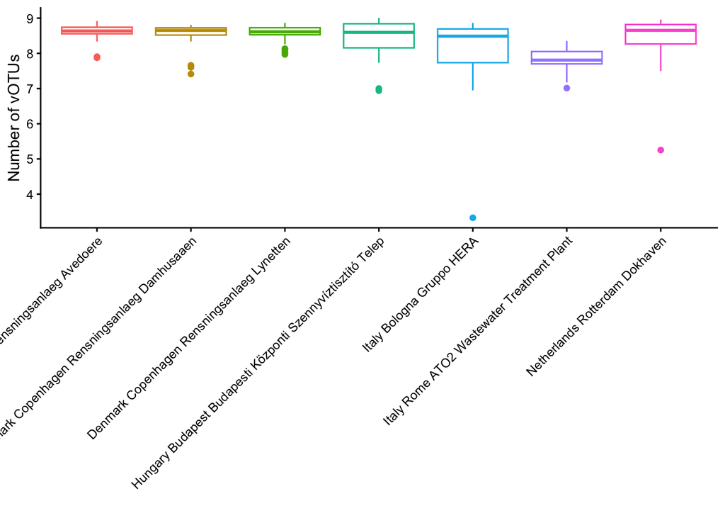

```r
ggplot(md, aes(x = site, y = viral_shannon)) +
  geom_boxplot(aes(color = site)) +
  xlab("") +
  ylab("Number of vOTUs") +
  theme_classic() +
  theme(legend.position = "none", axis.text.x = element_text(angle = 45, hjust = 1))
```

```r
# ggsave("CHANGE THIS PATH! /figures/viral_shannon_site.pdf", width = 5, height = 7, units = "in")
```

## 4.5 4.5 Differences per Site — Plasmids

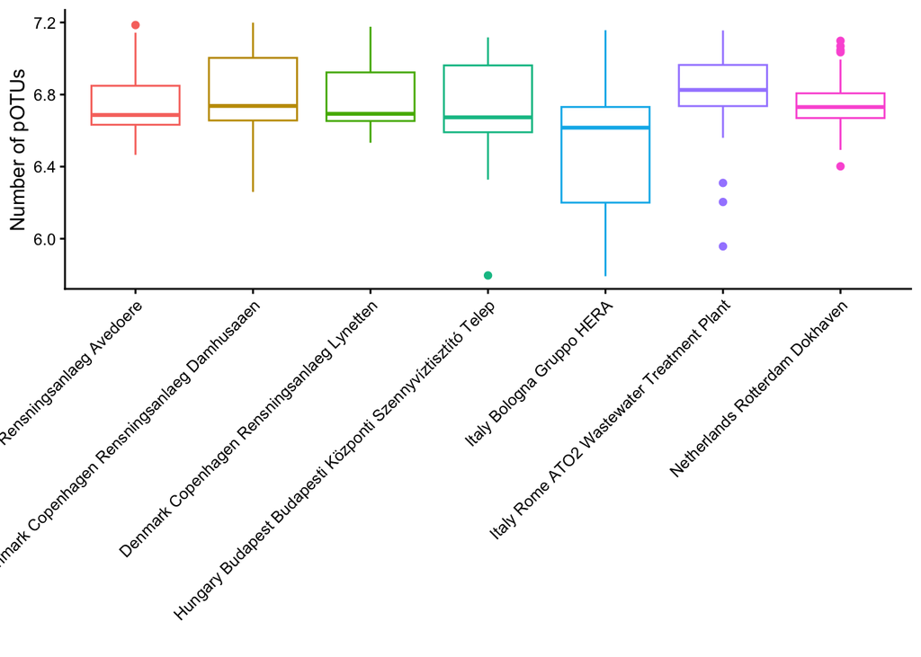

```r
ggplot(md, aes(x = site, y = plasmid_shannon)) +
  geom_boxplot(aes(color = site)) +
  xlab("") +
  ylab("Number of pOTUs") +
  theme_classic() +
  theme(legend.position = "none", axis.text.x = element_text(angle = 45, hjust = 1))
```

# 5 5. Community Composition

## 5.1 5.1 RPKM/TPM Abundance Normalization — Phages

```r
total_reads <- md %>%
  select(sample, total_reads)

# load votus length
votus_length <- read_csv("~/Documents/GitHub/ucd_bioinformaticscourse_2026/data/phages_summary.csv") %>%
  select(c("votu", "contig_length"))

# convert count table to long format
votus_count_long <- votus_clean %>%
  pivot_longer(cols = -c("sample"), values_to = "count", names_to = "votu")

votus_count_long_plusreads <- left_join(votus_count_long, total_reads, by = "sample")
votus_count_long_plusreads_pluslength <- left_join(votus_count_long_plusreads, votus_length, by = "votu")

# RPKM (for viral load)
rpkm_votu_count <- votus_count_long_plusreads_pluslength %>%
  mutate(RPKM = (count * 1e6) / (contig_length * total_reads)) %>%
  dplyr::select(-c("count", "total_reads", "contig_length")) %>%
  pivot_wider(names_from = "sample", values_from = "RPKM") %>%
  column_to_rownames(var = "votu") %>%
  drop_na()

# TPM (for composition comparisons, beta)
tpm_votu_count <- votus_count_long_plusreads_pluslength %>%
  mutate(RPK = (count * 1e6) / contig_length) %>%
  group_by(sample) %>%
  mutate(TPM = RPK / sum(RPK, na.rm = TRUE) * 1e6) %>%
  ungroup() %>%
  dplyr::select(-c("count", "total_reads", "contig_length", "RPK")) %>%
  pivot_wider(names_from = "sample", values_from = "TPM") %>%
  column_to_rownames(var = "votu") %>%
  drop_na()
```

## 5.2 5.2 RPKM Abundance Normalization — Plasmids

```r
potus_length <- read_csv("~/Documents/GitHub/ucd_bioinformaticscourse_2026/data/plasmids_summary.csv") %>%   # change for your selection
  select(c("seq_name", "length")) %>%
  rename(potu = seq_name)

potus_count_long <- potus_clean %>%
  pivot_longer(cols = -c("sample"), values_to = "count", names_to = "potu")

potus_count_long_plusreads <- left_join(potus_count_long, total_reads, by = "sample")
potus_count_long_plusreads_pluslength <- left_join(potus_count_long_plusreads, potus_length, by = "potu")

rpkm_potu_count <- potus_count_long_plusreads_pluslength %>%
  mutate(RPKM = (count * 1e9) / (length * total_reads)) %>%
  dplyr::select(-c("count", "total_reads", "length")) %>%
  pivot_wider(names_from = "sample", values_from = "RPKM") %>%
  column_to_rownames(var = "potu") %>%
  drop_na()
```

## 5.3 5.3 Community Composition — Phages

```r
viral.bray <- vegdist(t(rpkm_votu_count), method = "bray")

# ordination (non-metric multidimensional scaling)
viral.nmds <- metaMDS(viral.bray)
```

```
## *** Best solution was not repeated -- monoMDS stopping criteria:
##      2: no. of iterations >= maxit
##     15: stress ratio > sratmax
##      3: scale factor of the gradient < sfgrmin
```

```r
md$bracken.Axis01 <- viral.nmds$points[, 1]
md$bracken.Axis02 <- viral.nmds$points[, 2]
viral.nmds$stress # 0.1588582
```

```
## [1] 0.1028313
```

```r
# stats
adonis2(viral.bray ~ site, data = md, permutations = 999, method = "bray")
```

```
## Permutation test for adonis under reduced model
## Permutation: free
## Number of permutations: 999
##
## adonis2(formula = viral.bray ~ site, data = md, permutations = 999, method = "bray")
##           Df SumOfSqs     R2      F Pr(>F)
## Model      6   14.197 0.2273 13.189  0.001 ***
## Residual 269   48.262 0.7727
## Total    275   62.459 1.0000
## ---
## Signif. codes:  0 '***' 0.001 '**' 0.01 '*' 0.05 '.' 0.1 ' ' 1
```

### 5.3.1 Ordination Plot — Phages

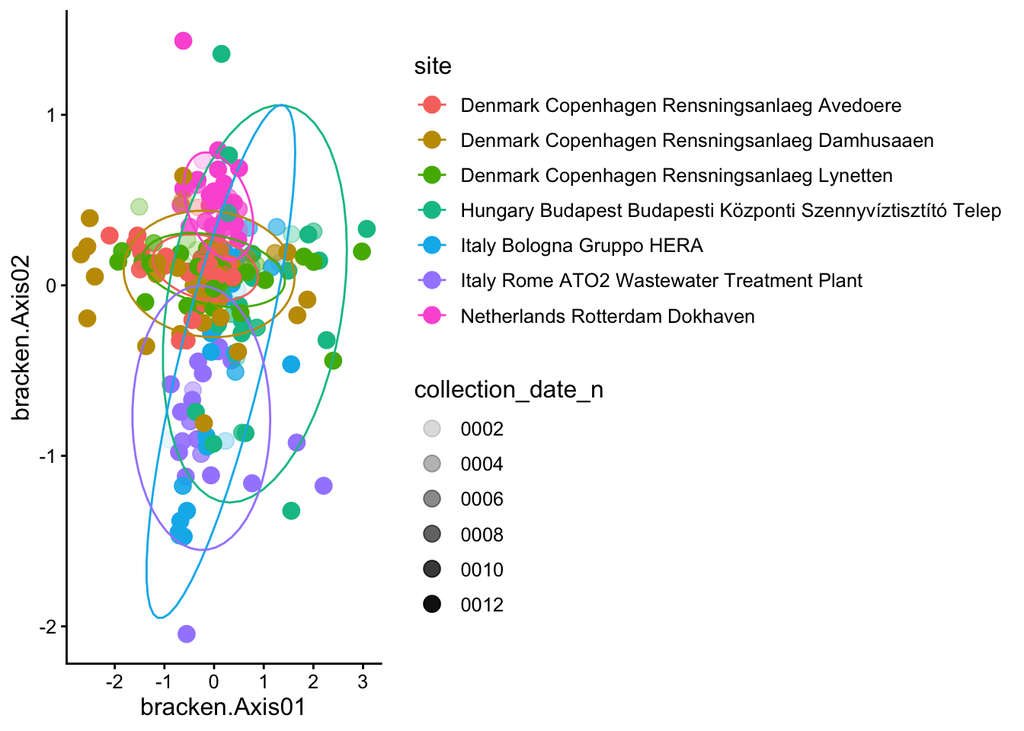

```r
ggplot(md, aes(bracken.Axis01, bracken.Axis02)) +
  geom_point(aes(alpha = collection_date_n, color = site), size = 3.5) +
  stat_ellipse(aes(color = site)) +
  theme_classic() +
  theme(legend.position = "right", text = element_text(size = 12))
```

```r
# ggsave("CHANGE THIS PATH! /viral_composition_bydate.pdf", device = "pdf", width = 9, height = 5, units = "in")
```

## 5.4 5.4 Community Composition — Plasmids

```r
plasmid.bray <- vegdist(t(rpkm_potu_count), method = "bray")

# ordination (non-metric multidimensional scaling)
plasmid.nmds <- metaMDS(plasmid.bray)
```

```
## *** Best solution repeated 1 times
```

```r
md$bracken.Axis01 <- plasmid.nmds$points[, 1]
md$bracken.Axis02 <- plasmid.nmds$points[, 2]
plasmid.nmds$stress # 0.1588582
```

```
## [1] 0.09565676
```

```r
# stats
adonis2(plasmid.bray ~ site, data = md, permutations = 999, method = "bray")
```

```
## Permutation test for adonis under reduced model
## Permutation: free
## Number of permutations: 999
##
## adonis2(formula = plasmid.bray ~ site, data = md, permutations = 999, method = "bray")
##           Df SumOfSqs      R2      F Pr(>F)
## Model      6   13.347 0.21718 12.438  0.001 ***
## Residual 269   48.109 0.78282
## Total    275   61.456 1.00000
## ---
## Signif. codes:  0 '***' 0.001 '**' 0.01 '*' 0.05 '.' 0.1 ' ' 1
```

### 5.4.1 Ordination Plot — Plasmids

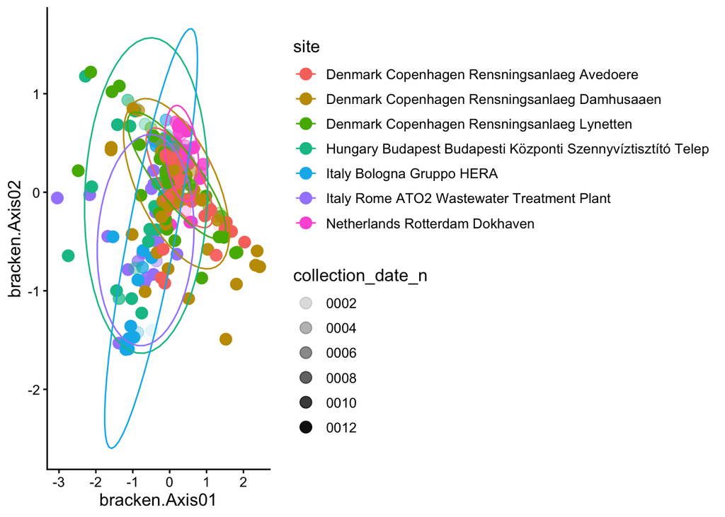

```r
ggplot(md, aes(bracken.Axis01, bracken.Axis02)) +
  geom_point(aes(alpha = collection_date_n, color = site), size = 3.5) +
  stat_ellipse(aes(color = site)) +
  theme_classic() +
  theme(legend.position = "right", text = element_text(size = 12))
```

```r
# ggsave("CHANGE THIS PATH!/plasmid_composition_bydate.pdf", device = "pdf", width = 9, height = 5, units = "in")
```

# 6 6. Extra Questions

Now that you’ve completed the workflow, you can try to answer the following questions:

1. What variables are determining viral and phage diversity and community composition, apart from the location and the time?
2. Do plasmid and viral diversity correlate?
3. Do their community compositions vary together?
4. What are the most abundant phages/plasmids? What is their length distribution?
5. Do we see changes in phage/plasmid abundance associated with their length? (i.e. are shorter viruses more abundant?)